# Categorical Summaries

Taylor Ledford

2018-09-06 13:03:34

Consider the Flight Delays dataset discussed in Chapter 1 of the Chihara & Hesterberg textbook, which contains information on selected flights departing from LaGuardia airport in 2009. Complete the problems below using that dataset. For all plots, be sure to add an informative title and labels for the x and y axes.

```r
library(dplyr)
```

```r
library(ggplot2)
FlightDelays <- read.csv("https://raw.githubusercontent.com/STAT-JET-ASU/Datasets/master/Chihara/FlightDelays.csv")
```

### Problem 1

Create frequency tables for all of the qualitative variables.

```r
table(FlightDelays$Carrier)
```

```
##
##   AA   UA
## 2906 1123
```

```r
table(FlightDelays$Destination)
```

```
##
##  BNA  DEN  DFW  IAD  MIA  ORD  STL
##  172  264  918   55  610 1785  225
```

```r
table(FlightDelays$DepartTime)
```

```
##
##    4-8am    4-8pm    8-Mid   8-Noon Noon-4pm
##      699      972      257     1053     1048
```

```r
table(FlightDelays$Day)
```

```
##
## Fri Mon Sat Sun Thu Tue Wed
## 637 630 453 551 566 628 564
```

```r
table(FlightDelays$Month)
```

```
##
## June  May
## 2030 1999
```

```r
table(FlightDelays$Delayed30)
```

```
##
##   No  Yes
## 3432  597
```

### Problem 2

Create a barplot to display the frequency of each destination.

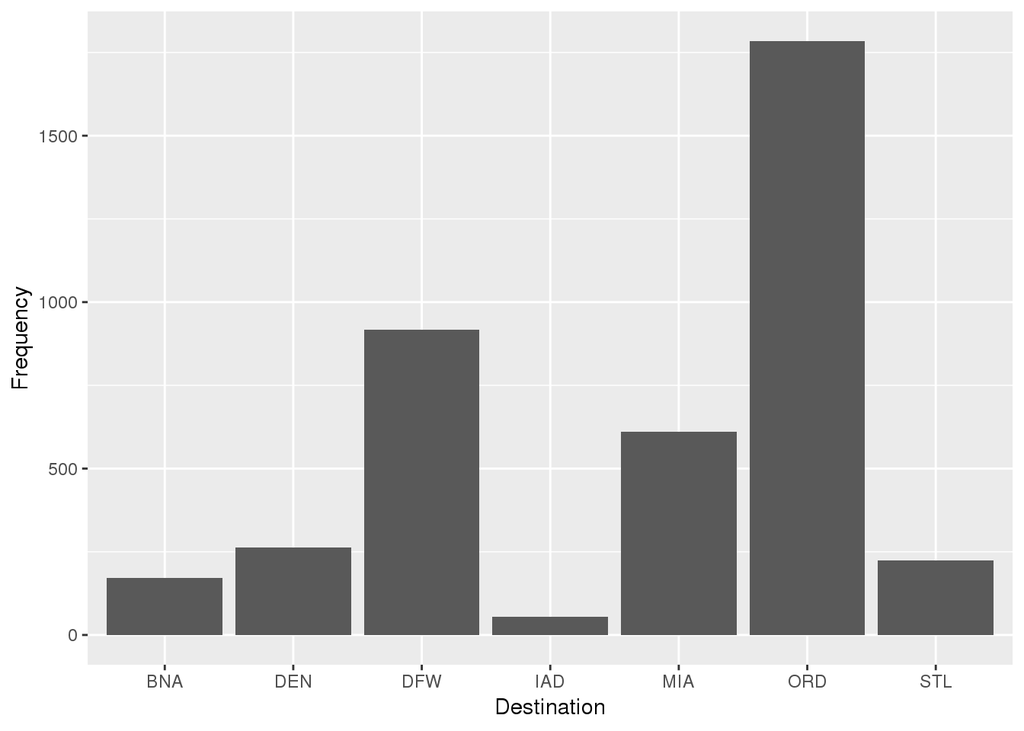

```r
freq <- FlightDelays %>% count(Destination)
ggplot(freq, aes(x=Destination, y=n)) +
  geom_bar(stat="identity") +
  ylab("Frequency")
```

### Problem 3

Create a barplot to show the relative frequency of each destination.

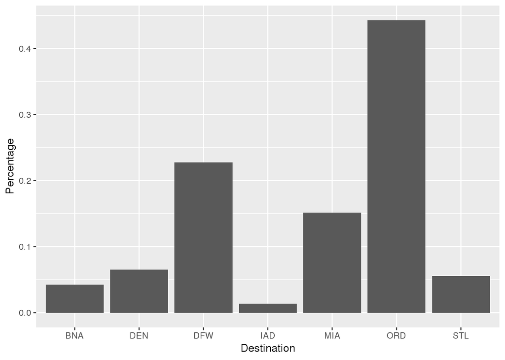

```r
total <- sum(freq$n)
freq$m <- freq$n/total
ggplot(freq, aes(x=Destination, y=m)) +
  geom_bar(stat="identity") +
  ylab("Percentage")
```

### Problem 4

Use the information found [HERE](http://www.cookbook-r.com/Manipulating_data/Changing_the_order_of_levels_of_a_factor/) to reorder the levels of the departure time variable so they start at 4am and go in order around the clock. Then create a table that shows cumulative frequency of flights through the day and a barplot that shows the fraction of flights within each time period that are delayed by thirty minutes or more.

```r
FlightDelays$DepartTime <- ordered(FlightDelays$DepartTime, levels=c("4-8am","8-Noon","Noon-4pm","4-8pm","8-Mid"))
freqTime <- table(FlightDelays$DepartTime)
cumsum(freqTime)
```

```
##    4-8am   8-Noon Noon-4pm    4-8pm    8-Mid
##      699     1752     2800     3772     4029
```

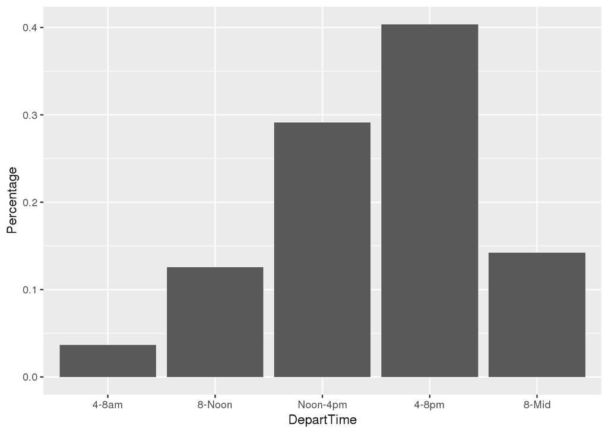

```r
m <- FlightDelays %>%
      filter(Delayed30=="Yes") %>%
      group_by(DepartTime) %>%
      count()

ggplot(m, aes(x=DepartTime, y=n/sum(n))) +
  geom_bar(stat="identity") +
  ylab("Percentage")
```

### Problem 5

For two qualitative variables of your choice, create a table and a plot to summarize their relationship. What is one question your summaries might help answer?

My summary gives an answer to which carrier has more delays that are 30 minutes or longer.

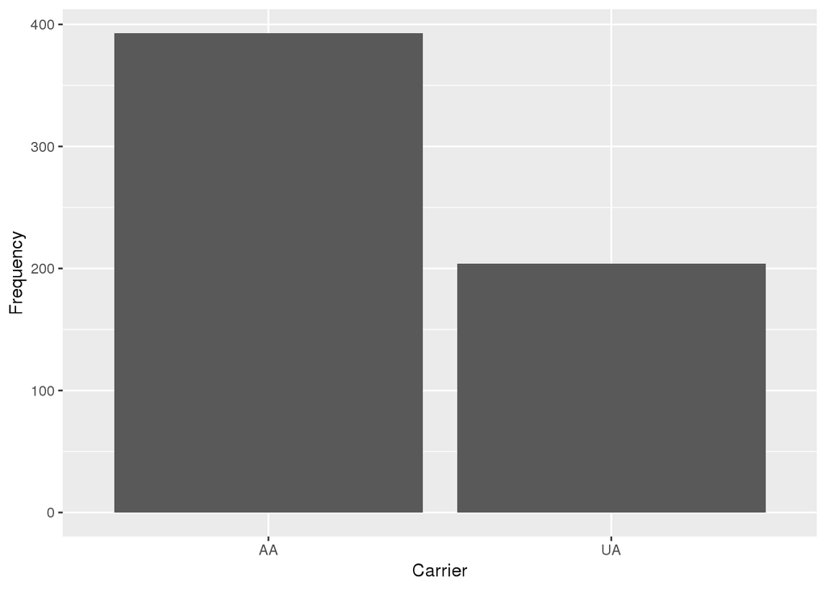

```r
x <- FlightDelays %>%
  filter(Delayed30=="Yes") %>%
  group_by(Carrier) %>%
  count()

ggplot(x, aes(x=Carrier, y=n)) +
  geom_bar(stat="identity") +
  ylab("Frequency")
```

END!!!